# Mobile Phone Price Analysis Using R

Ansh Sharma

2026-09-22

# 1. Introduction

Mobile phones are available in a wide range of prices and specifications. This project uses R to explore a sample dataset of mobile phones and study how specifications such as RAM, storage, battery capacity and rating are related to price.

The main objectives are to import and clean the data, calculate descriptive statistics, create graphs, examine relationships between variables, and interpret the results.

> **Dataset note:** The CSV included with this project is a curated sample dataset prepared for academic demonstration. Prices and specifications should be treated as sample analytical data, not as a live market-price database.

# 2. Required Packages

```r
knitr::opts_chunk$set(echo = TRUE, warning = FALSE, message = FALSE)

if (!requireNamespace("ggplot2", quietly = TRUE)) {
  stop("Please install ggplot2 using install.packages('ggplot2') before knitting.")
}

library(ggplot2)
```

The project uses `ggplot2` for clear and readable visualizations.

# 3. Importing the Dataset

```r
mobile_data <- read.csv("data/mobile_phone_data.csv",
                        stringsAsFactors = FALSE)

head(mobile_data)
```

```
##     Brand         Model Price RAM Storage Battery Camera Display_Size Rating
## 1 Samsung    Galaxy A15 14999   6     128    5000     50          6.5    4.2
## 2 Samsung    Galaxy A25 22999   8     128    5000     50          6.5    4.3
## 3 Samsung    Galaxy M35 19999   8     128    6000     50          6.6    4.4
## 4 Samsung Galaxy S23 FE 44999   8     128    4500     50          6.4    4.5
## 5 Samsung    Galaxy S24 74999   8     256    4000     50          6.2    4.6
## 6   Apple     iPhone 13 52999   4     128    3227     12          6.1    4.6
##   X5G
## 1 Yes
## 2 Yes
## 3 Yes
## 4 Yes
## 5 Yes
## 6 Yes
```

The `read.csv()` function imports the CSV file. The relative path makes the project portable when the complete folder is uploaded to GitHub.

# 4. Understanding the Dataset

```r
str(mobile_data)
```

```
## 'data.frame':    44 obs. of  10 variables:
##  $ Brand       : chr  "Samsung" "Samsung" "Samsung" "Samsung" ...
##  $ Model       : chr  "Galaxy A15" "Galaxy A25" "Galaxy M35" "Galaxy S23 FE" ...
##  $ Price       : int  14999 22999 19999 44999 74999 52999 59999 69999 79999 99999 ...
##  $ RAM         : int  6 8 8 8 8 4 6 6 6 8 ...
##  $ Storage     : int  128 128 128 128 256 128 128 128 128 256 ...
##  $ Battery     : int  5000 5000 6000 4500 4000 3227 3279 3349 4383 3274 ...
##  $ Camera      : int  50 50 50 50 50 12 12 48 48 48 ...
##  $ Display_Size: num  6.5 6.5 6.6 6.4 6.2 6.1 6.1 6.1 6.7 6.1 ...
##  $ Rating      : num  4.2 4.3 4.4 4.5 4.6 4.6 4.6 4.7 4.7 4.8 ...
##  $ X5G         : chr  "Yes" "Yes" "Yes" "Yes" ...
```

```r
cat("Number of rows:", nrow(mobile_data), "\n")
```

```
## Number of rows: 44
```

```r
cat("Number of columns:", ncol(mobile_data), "\n")
```

```
## Number of columns: 10
```

```r
summary(mobile_data)
```

```
##        Brand          Model        Price             RAM
##  Length   :44   Length   :44   Min.   :  9999   Min.   : 4.000
##  N.unique :10   N.unique :43   1st Qu.: 22999   1st Qu.: 8.000
##  N.blank  : 0   N.blank  : 0   Median : 32499   Median : 8.000
##  Min.nchar: 4   Min.nchar: 2   Mean   : 42294   Mean   : 8.545
##  Max.nchar: 8   Max.nchar:17   3rd Qu.: 60999   3rd Qu.: 8.000
##                                Max.   :139999   Max.   :16.000
##     Storage         Battery         Camera        Display_Size
##  Min.   :128.0   Min.   :3227   Min.   : 12.00   Min.   :6.100
##  1st Qu.:128.0   1st Qu.:4556   1st Qu.: 50.00   1st Qu.:6.500
##  Median :128.0   Median :5000   Median : 50.00   Median :6.700
##  Mean   :194.9   Mean   :4960   Mean   : 54.41   Mean   :6.609
##  3rd Qu.:256.0   3rd Qu.:5500   3rd Qu.: 50.00   3rd Qu.:6.772
##  Max.   :512.0   Max.   :7300   Max.   :200.00   Max.   :7.800
##      Rating             X5G
##  Min.   :4.100   Length   :44
##  1st Qu.:4.400   N.unique : 1
##  Median :4.500   N.blank  : 0
##  Mean   :4.495   Min.nchar: 3
##  3rd Qu.:4.600   Max.nchar: 3
##  Max.   :4.800
```

The dataset contains brand and model information along with numerical specifications such as price, RAM, storage, battery, camera resolution, display size and rating.

# 5. Data Preprocessing and Cleaning

## 5.1 Checking Missing Values

```r
colSums(is.na(mobile_data))
```

```
##        Brand        Model        Price          RAM      Storage      Battery
##            0            0            0            0            0            0
##       Camera Display_Size       Rating          X5G
##            0            0            0            0
```

The result is checked to make sure that the important analytical variables do not contain missing values.

## 5.2 Checking Duplicate Records

```r
sum(duplicated(mobile_data))
```

```
## [1] 0
```

Duplicate rows can affect statistical results, so they are checked before analysis.

## 5.3 Checking Data Types

```r
sapply(mobile_data, class)
```

```
##        Brand        Model        Price          RAM      Storage      Battery
##  "character"  "character"    "integer"    "integer"    "integer"    "integer"
##       Camera Display_Size       Rating          X5G
##    "integer"    "numeric"    "numeric"  "character"
```

The data types are reviewed to make sure that numerical variables can be used for statistical calculations.

## 5.4 Basic Cleaning

```r
mobile_data$Brand <- trimws(mobile_data$Brand)
mobile_data$Model <- trimws(mobile_data$Model)

mobile_data$Price <- as.numeric(mobile_data$Price)
mobile_data$RAM <- as.numeric(mobile_data$RAM)
mobile_data$Storage <- as.numeric(mobile_data$Storage)
mobile_data$Battery <- as.numeric(mobile_data$Battery)
mobile_data$Camera <- as.numeric(mobile_data$Camera)
mobile_data$Display_Size <- as.numeric(mobile_data$Display_Size)
mobile_data$Rating <- as.numeric(mobile_data$Rating)

mobile_data <- mobile_data[complete.cases(mobile_data), ]

cat("Rows after cleaning:", nrow(mobile_data))
```

```
## Rows after cleaning: 44
```

The cleaning step removes leading/trailing spaces and ensures that analytical columns are numeric. Complete records are retained for the analysis.

# 6. Statistical Analysis

## 6.1 Descriptive Statistics

```r
numeric_data <- mobile_data[, c("Price", "RAM", "Storage",
                                "Battery", "Camera",
                                "Display_Size", "Rating")]

stats_table <- data.frame(
  Variable = names(numeric_data),
  Mean = sapply(numeric_data, mean),
  Median = sapply(numeric_data, median),
  Variance = sapply(numeric_data, var),
  Standard_Deviation = sapply(numeric_data, sd)
)

knitr::kable(stats_table,
             digits = 2,
             caption = "Descriptive Statistics")
```

Descriptive Statistics

|  | Variable | Mean | Median | Variance | Standard_Deviation |
| --- | --- | --- | --- | --- | --- |
| Price | Price | 42294.45 | 32499.0 | 738119978.86 | 27168.36 |
| RAM | RAM | 8.55 | 8.0 | 6.58 | 2.57 |
| Storage | Storage | 194.91 | 128.0 | 11041.01 | 105.08 |
| Battery | Battery | 4959.75 | 5000.0 | 604837.03 | 777.71 |
| Camera | Camera | 54.41 | 50.0 | 671.92 | 25.92 |
| Display_Size | Display_Size | 6.61 | 6.7 | 0.09 | 0.31 |
| Rating | Rating | 4.50 | 4.5 | 0.03 | 0.16 |

Mean gives the average value, median gives the middle value, variance measures spread, and standard deviation shows how much values vary around the mean.

## 6.2 Price by Brand

```r
brand_summary <- aggregate(Price ~ Brand, data = mobile_data, FUN = mean)
brand_summary <- brand_summary[order(-brand_summary$Price), ]

knitr::kable(brand_summary,
             digits = 2,
             caption = "Average Price by Brand")
```

Average Price by Brand

|  | Brand | Price |
| --- | --- | --- |
| 1 | Apple | 72599 |
| 2 | Google | 63249 |
| 5 | OnePlus | 59999 |
| 6 | Oppo | 38749 |
| 8 | Samsung | 35599 |
| 9 | Vivo | 35249 |
| 4 | Motorola | 33749 |
| 3 | iQOO | 32749 |
| 7 | Realme | 25749 |
| 10 | Xiaomi | 20399 |

This table compares the average sample price across brands. Differences may reflect the range of models represented by each brand.

# 7. Data Visualization

## 7.1 Price Distribution

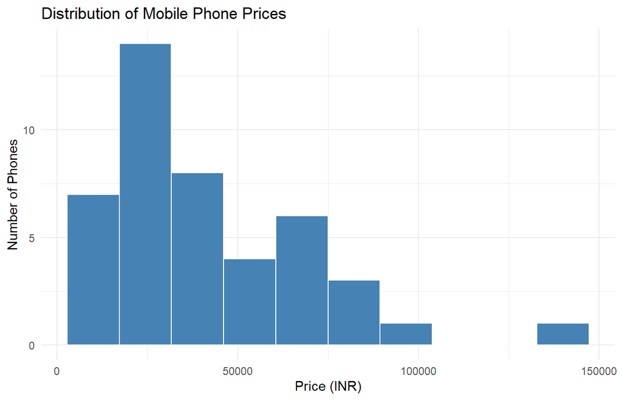

```r
ggplot(mobile_data, aes(x = Price)) +
  geom_histogram(bins = 10, fill = "steelblue", color = "white") +
  labs(title = "Distribution of Mobile Phone Prices",
       x = "Price (INR)", y = "Number of Phones") +
  theme_minimal()
```

The histogram shows how the sample phones are distributed across price ranges. A wider spread indicates that the dataset contains both budget and premium phones.

## 7.2 Average Price by Brand

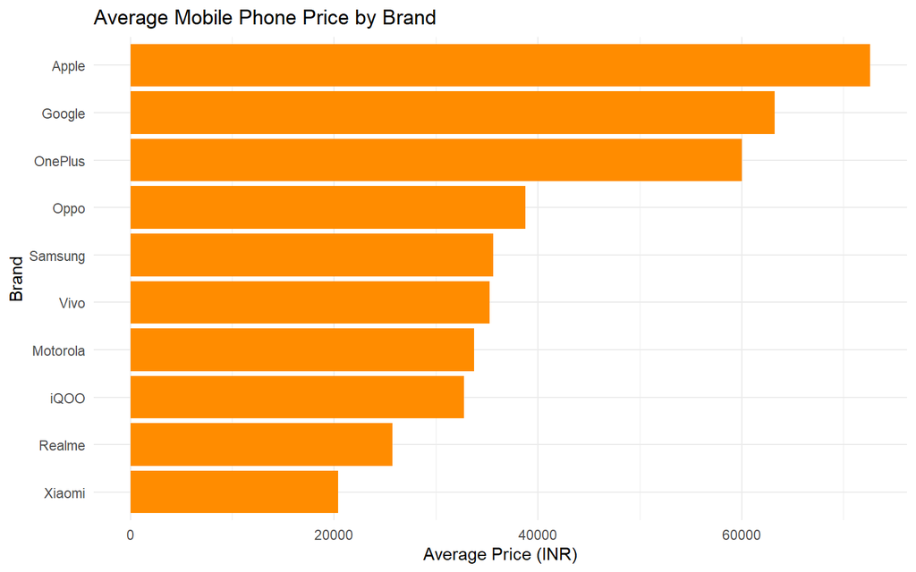

```r
ggplot(brand_summary,
       aes(x = reorder(Brand, Price), y = Price)) +
  geom_col(fill = "darkorange") +
  coord_flip() +
  labs(title = "Average Mobile Phone Price by Brand",
       x = "Brand", y = "Average Price (INR)") +
  theme_minimal()
```

The bar chart makes it easier to compare the average sample price of different brands.

## 7.3 RAM Distribution

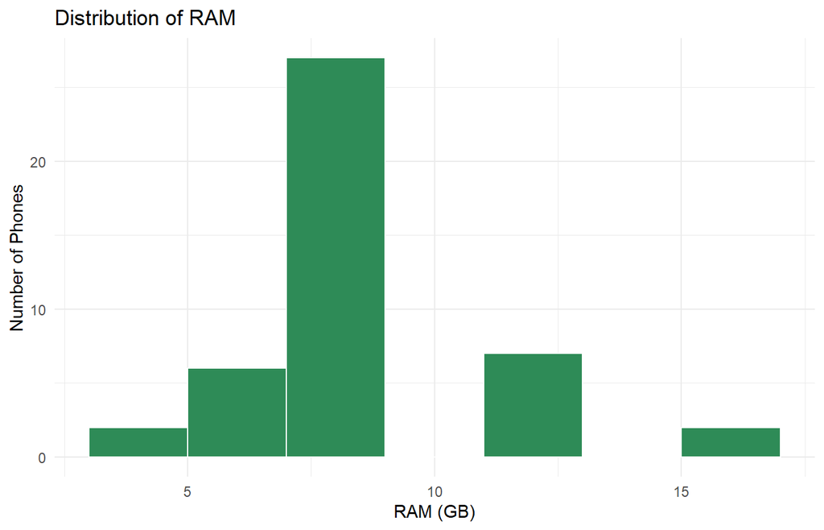

```r
ggplot(mobile_data, aes(x = RAM)) +
  geom_histogram(binwidth = 2, fill = "seagreen", color = "white") +
  labs(title = "Distribution of RAM",
       x = "RAM (GB)", y = "Number of Phones") +
  theme_minimal()
```

The RAM distribution shows which memory configurations are common in the sample.

## 7.4 Storage Distribution

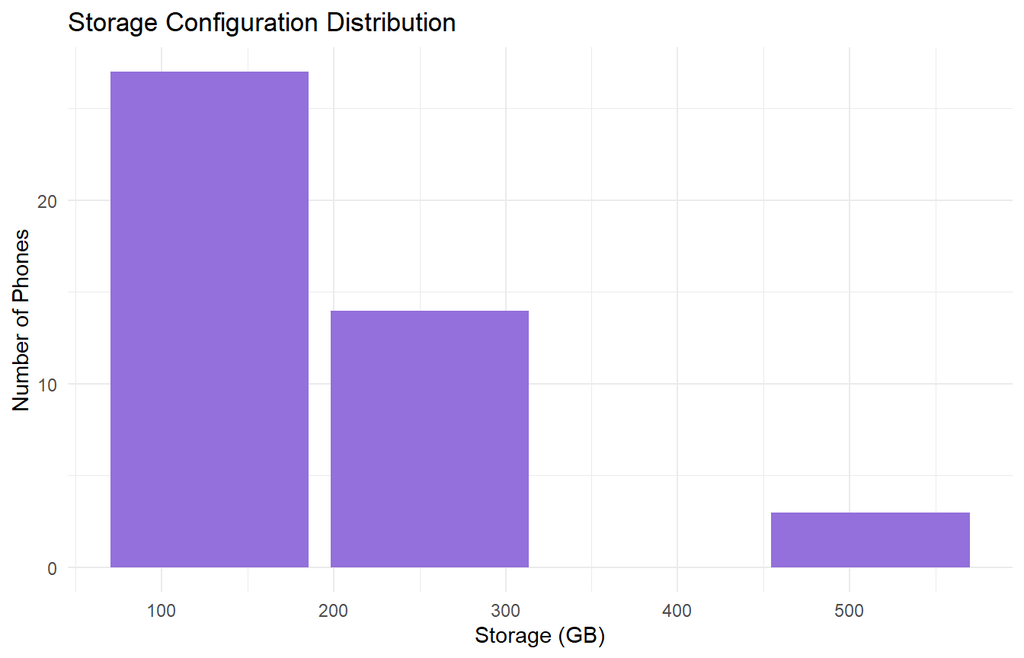

```r
ggplot(mobile_data, aes(x = Storage)) +
  geom_bar(fill = "mediumpurple") +
  labs(title = "Storage Configuration Distribution",
       x = "Storage (GB)", y = "Number of Phones") +
  theme_minimal()
```

The graph shows how frequently different storage capacities occur.

## 7.5 RAM vs Price

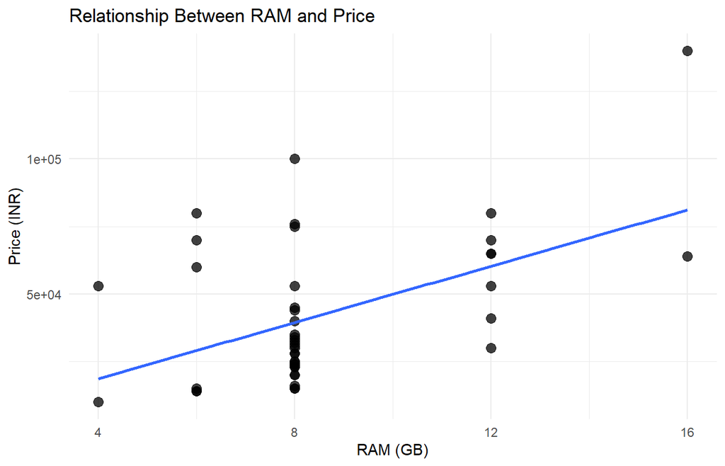

```r
ggplot(mobile_data, aes(x = RAM, y = Price)) +
  geom_point(size = 3, alpha = 0.75) +
  geom_smooth(method = "lm", se = FALSE) +
  labs(title = "Relationship Between RAM and Price",
       x = "RAM (GB)", y = "Price (INR)") +
  theme_minimal()
```

The scatter plot helps identify whether phones with higher RAM tend to have higher prices in the sample. The fitted line summarizes the overall linear trend but does not prove that RAM alone causes price differences.

## 7.6 Storage vs Price

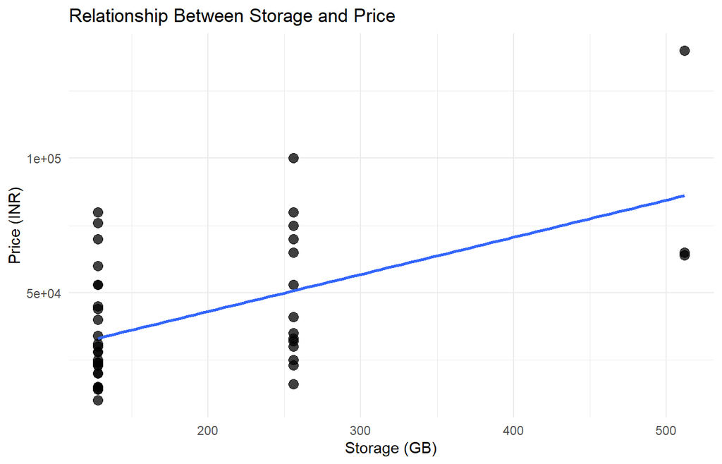

```r
ggplot(mobile_data, aes(x = Storage, y = Price)) +
  geom_point(size = 3, alpha = 0.75) +
  geom_smooth(method = "lm", se = FALSE) +
  labs(title = "Relationship Between Storage and Price",
       x = "Storage (GB)", y = "Price (INR)") +
  theme_minimal()
```

This plot examines whether larger storage capacity is associated with higher sample prices.

## 7.7 Battery vs Price

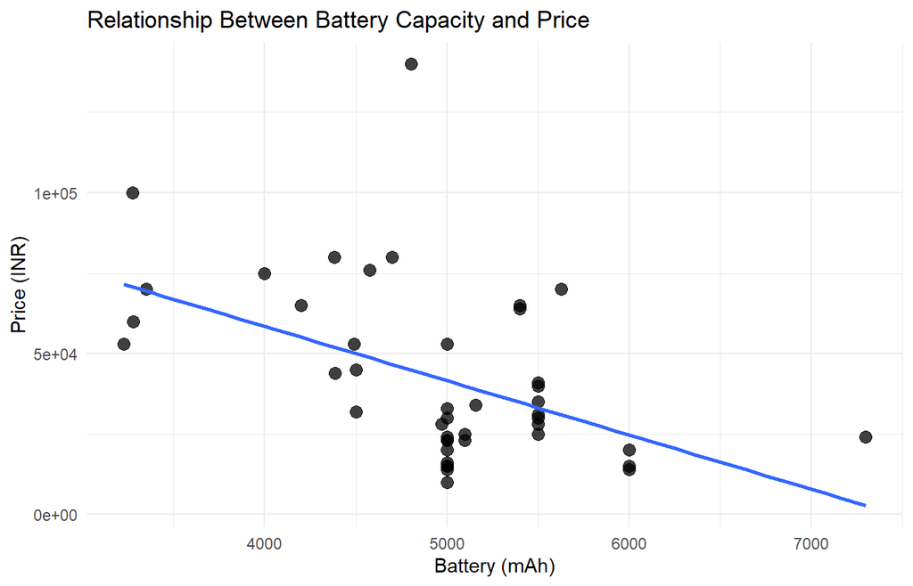

```r
ggplot(mobile_data, aes(x = Battery, y = Price)) +
  geom_point(size = 3, alpha = 0.75) +
  geom_smooth(method = "lm", se = FALSE) +
  labs(title = "Relationship Between Battery Capacity and Price",
       x = "Battery (mAh)", y = "Price (INR)") +
  theme_minimal()
```

Battery capacity is compared with price to see whether a simple relationship is visible in the sample.

## 7.8 Price vs Rating

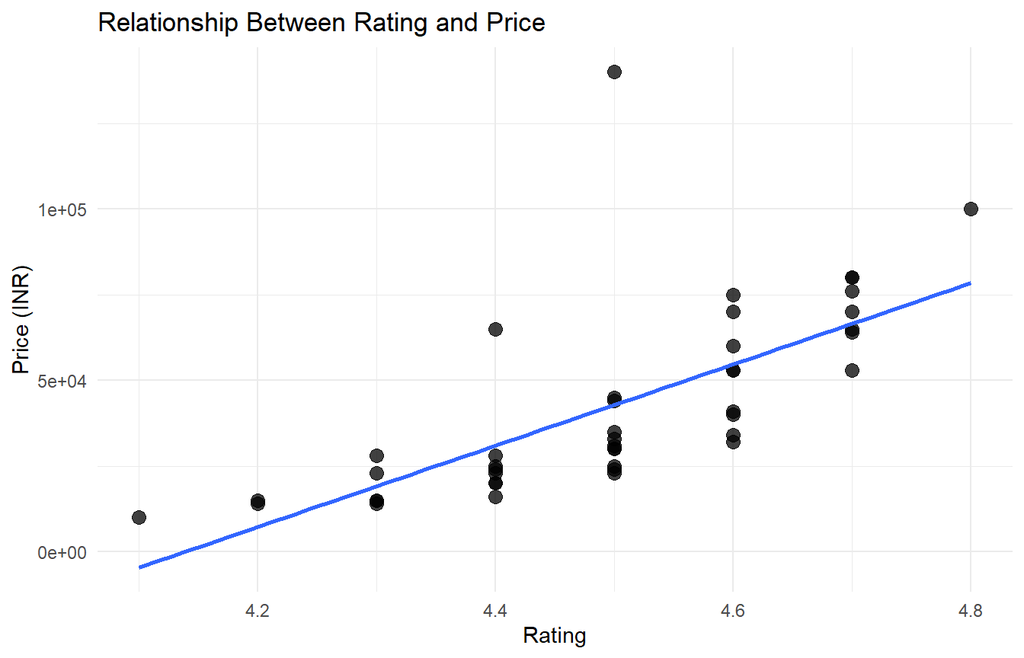

```r
ggplot(mobile_data, aes(x = Rating, y = Price)) +
  geom_point(size = 3, alpha = 0.75) +
  geom_smooth(method = "lm", se = FALSE) +
  labs(title = "Relationship Between Rating and Price",
       x = "Rating", y = "Price (INR)") +
  theme_minimal()
```

The graph compares user-rating values in the sample with phone prices. Rating and price may move together in the sample, but the relationship can also be affected by brand, model category and specifications.

# 8. Correlation Analysis

```r
correlation_matrix <- cor(
  mobile_data[, c("Price", "RAM", "Storage",
                  "Battery", "Camera",
                  "Display_Size", "Rating")]
)

knitr::kable(round(correlation_matrix, 2),
             caption = "Correlation Matrix")
```

Correlation Matrix

|  | Price | RAM | Storage | Battery | Camera | Display_Size | Rating |
| --- | --- | --- | --- | --- | --- | --- | --- |
| Price | 1.00 | 0.49 | 0.53 | -0.48 | -0.21 | 0.00 | 0.69 |
| RAM | 0.49 | 1.00 | 0.79 | 0.20 | 0.00 | 0.49 | 0.36 |
| Storage | 0.53 | 0.79 | 1.00 | -0.08 | 0.06 | 0.46 | 0.27 |
| Battery | -0.48 | 0.20 | -0.08 | 1.00 | 0.17 | 0.52 | -0.37 |
| Camera | -0.21 | 0.00 | 0.06 | 0.17 | 1.00 | 0.14 | -0.14 |
| Display_Size | 0.00 | 0.49 | 0.46 | 0.52 | 0.14 | 1.00 | -0.26 |
| Rating | 0.69 | 0.36 | 0.27 | -0.37 | -0.14 | -0.26 | 1.00 |

Correlation values range from -1 to +1. Values closer to +1 indicate a stronger positive linear relationship, values closer to -1 indicate a stronger negative relationship, and values near 0 indicate a weak linear relationship.

## 8.1 Key Correlations with Price

```r
price_correlations <- correlation_matrix["Price", ]
price_correlations <- sort(price_correlations, decreasing = TRUE)

knitr::kable(round(price_correlations, 2),
             caption = "Correlation of Variables with Price")
```

Correlation of Variables with Price

|  | x |
| --- | --- |
| Price | 1.00 |
| Rating | 0.69 |
| Storage | 0.53 |
| RAM | 0.49 |
| Display_Size | 0.00 |
| Camera | -0.21 |
| Battery | -0.48 |

This table provides a quick view of which numerical variables have stronger linear association with price in this sample.

# 9. Findings

```r
avg_price <- mean(mobile_data$Price)
median_price <- median(mobile_data$Price)
ram_price_cor <- cor(mobile_data$RAM, mobile_data$Price)
storage_price_cor <- cor(mobile_data$Storage, mobile_data$Price)

cat("Average price:", round(avg_price, 2), "INR\n")
```

```
## Average price: 42294.45 INR
```

```r
cat("Median price:", round(median_price, 2), "INR\n")
```

```
## Median price: 32499 INR
```

```r
cat("RAM-Price correlation:", round(ram_price_cor, 2), "\n")
```

```
## RAM-Price correlation: 0.49
```

```r
cat("Storage-Price correlation:", round(storage_price_cor, 2), "\n")
```

```
## Storage-Price correlation: 0.53
```

The analysis can be summarized as follows:

1. The sample contains phones across budget, mid-range and premium price levels.
2. Price varies substantially across the selected models.
3. RAM and storage can show positive relationships with price in the sample, but they are not the only factors affecting price.
4. Brand, camera, battery, display and product positioning can also contribute to price differences.
5. Correlation describes association, not causation.

# 10. Conclusion

This project demonstrates how R can be used for a complete data-analysis workflow. The mobile-phone dataset was imported from CSV, inspected, cleaned and statistically explored. Descriptive statistics and visualizations were then used to understand price distribution and relationships between price and selected specifications.

The project also demonstrates the importance of interpreting graphs and correlation values rather than looking only at raw numbers. Because the dataset is a curated academic sample, the findings should be treated as an analytical demonstration rather than a real-time market study.

# 11. Future Scope

The project can be extended by adding more phones and additional variables such as processor, refresh rate, operating system, launch year, discount and customer-review count. A larger real-world dataset could also be used for regression or machine-learning models to estimate phone prices.

# 12. Reproducibility

The project uses a relative dataset path:

```r
cat("Dataset path: data/mobile_phone_data.csv\n")
```

```
## Dataset path: data/mobile_phone_data.csv
```

Keep the `.Rmd` file and the `data` folder in the same project directory before knitting the report.